# Model estimation

# Model estimation

This file follows `03_descriptive_analysis.qmd`. We estimate the four block models chosen in 03 on the full sample and run the checks we report. Everything here is **in-sample**: the parameters are estimated once on 2000Q1–2026Q3.

The steps are:

1. **Seasonal adjustment and estimation**: X-13 on each block, then the ARIMAs and the oil ECM on the adjusted series.
2. **ARIMA blocks**: coefficients and residual checks.
3. **Oil ECM**: long-run relation, short-run dynamics, cointegration and exogeneity tests.
4. **Check of the forecast recursion**: our own forecast code gives the same numbers as R.
5. **Re-aggregation check**: the four blocks rebuild headline CPI.

All functions used here (`fit_blocks()`, `arima_paths()`, …) are in `R/models.R`, so that 04, 05 and 06 estimate exactly the same models.

```r
library(here)
library(tidyverse)
library(urca)       # ur.df() (ADF), ca.jo() (Johansen), cajorls() (VECM)
library(tseries)    # jarque.bera.test()
source(here("R", "models.R"))

# Parameters. When the project is run with main.R, its values are used;
# otherwise the same values are set here so the file can be rendered alone.
if (!inherits(get0("start_estimation"), "Date")) start_estimation <- as.Date("2000-01-01")
if (!exists("fcst_horizon"))     fcst_horizon     <- 12
if (!all(c("rent", "imp_xoil", "dom_xrent") %in% names(get0("arima_specs")))) {
  arima_specs <- list(rent      = list(order = c(3, 1, 0)),
                      imp_xoil  = list(order = c(0, 1, 2),
                                       dummy = c(from = "2009-01-01", to = "2016-10-01")),
                      dom_xrent = list(order = c(1, 1, 1)),
                      headline  = list(order = c(0, 1, 1)))
}

dir.create(here("output"), showWarnings = FALSE)

# Quarterly data from 2000Q1, with logs x 100 and the block weights
q <- load_quarterly(start_estimation)
range(q$date)
```

```
[1] "2000-01-01" "2026-07-01"
```

```r
nrow(q)
```

```
[1] 107
```

# 1. Seasonal adjustment and estimation

```r
# X-13 on each block, then the ARIMAs and the ECM on the adjusted series.
# fit_blocks() is the same function used by 05 (forecast) and 06 (evaluation).
fits <- fit_blocks(q, fcst_horizon, arima_specs)

sa         <- lapply(fits$adj, function(a) a$sa)   # adjusted log levels
arima_fits <- fits$arima                           # rents, imported, domestic
ecm        <- fits$ecm                             # oil products

# X-13 result per block: automatic model, seasonality found, outliers
imap_dfr(fits$adj, function(a, b) {
  tibble(block     = b,
         x13_model = a$model$model$arima$model,
         seasonal  = any(a$sf_fc != 0),
         outliers  = paste(grep("^(AO|LS|TC)", names(coef(a$model)), value = TRUE),
                           collapse = ", "))
}) %>%
  as.data.frame()
```

```
      block      x13_model seasonal outliers
1       oil (0 1 1)(0 1 1)     TRUE
2      rent        (1 1 2)    FALSE LS2000.4
3  imp_xoil (2 1 1)(1 0 1)     TRUE LS2011.4
4 dom_xrent (1 1 0)(0 1 1)     TRUE LS2023.1
```

The X-13 results are the same as in section 3.2 of 03: oil products, imported and domestic goods are adjusted, rents are not (no seasonality). X-13 detects level shifts in 2000Q4 (rents), 2011Q4 (imported goods) and 2023Q1 (domestic goods).

# 2. ARIMA blocks

```r
# The orders are set in main.R (arima_specs), selected by BIC in 03.
# Coefficients with standard errors and t-statistics
arima_table <- imap_dfr(arima_fits, function(fit, b) {
  se <- sqrt(diag(fit$var.coef))
  tibble(block = b, term = names(coef(fit)), estimate = coef(fit),
         std_error = se, t_stat = coef(fit) / se)
})
arima_table %>%
  mutate(across(where(is.double), ~ round(.x, 3))) %>%
  as.data.frame()
```

```
       block  term estimate std_error t_stat
1       rent   ar1    0.847     0.092  9.232
2       rent   ar2   -0.472     0.117 -4.031
3       rent   ar3    0.350     0.097  3.617
4       rent drift    0.361     0.067  5.381
5   imp_xoil   ma1    0.129     0.087  1.480
6   imp_xoil   ma2    0.400     0.098  4.090
7   imp_xoil drift    0.026     0.092  0.280
8   imp_xoil dummy   -0.533     0.162 -3.285
9  dom_xrent   ar1    0.826     0.076 10.799
10 dom_xrent   ma1   -0.446     0.113 -3.967
11 dom_xrent drift    0.147     0.056  2.642
```

```r
# Fit and residual checks per block, two separate tests:
#   Ljung-Box on 8 lags (two years), degrees of freedom corrected for the
#     number of ARMA coefficients. H0 = no autocorrelation in the residuals.
#   Jarque-Bera. H0 = normal residuals (skewness 0, kurtosis 3).
diagnostics <- imap_dfr(arima_fits, function(fit, b) {
  k  <- sum(fit$arma[1:4])
  lb <- Box.test(residuals(fit), lag = 8, type = "Ljung-Box", fitdf = k)
  jb <- jarque.bera.test(residuals(fit))
  tibble(block = b, aic = AIC(fit), bic = BIC(fit),
         ljung_box_p = lb$p.value, jarque_bera_p = jb$p.value)
})
diagnostics %>%
  mutate(across(where(is.double), ~ round(.x, 3))) %>%
  as.data.frame()
```

```
      block     aic     bic ljung_box_p jarque_bera_p
1      rent -33.944 -20.627       0.834         0.001
2  imp_xoil 175.193 188.511       0.198         0.001
3 dom_xrent -46.975 -36.321       0.187         0.000
```

```r
write_csv(left_join(arima_table, diagnostics, by = "block"),
          here("output", "estimates_arima.csv"))
```

From script 03:

- **Rents, ARIMA(3,1,0)**: three significant AR terms and a drift of 0.36 % per quarter (about 1.4 % per year).
- **Imported excl. oil, ARIMA(0,1,2) with a dummy for 2009Q1–2016Q4**: a significant second MA term (0.40). The dummy captures the strong-franc period: growth was 0.53 pp lower per quarter during these years (t = −3.3). Outside this period the drift is close to zero (0.03 % per quarter), which is the growth used in the forecast.
- **Domestic excl. rents, ARIMA(1,1,1)**: ar1 = 0.83, ma1 = −0.45 and a significant drift of 0.15 % per quarter.

No block shows autocorrelation left in the residuals (Ljung-Box p = 0.83, 0.20 and 0.19). Normality, however, is rejected for all three blocks (Jarque-Bera p ≤ 0.001). The non-normality comes from a few extreme quarters, the level shifts detected by X-13 (2000Q4 for rents, 2011Q4 for imported goods, 2023Q1 for domestic goods), which remain in the adjusted series.

# 3. Oil ECM

The ECM is estimated in two steps (Engle-Granger), on seasonally adjusted oil products. Brent and the USD rate are not seasonal and are used as they are.

```r
# Step 1: long-run relation
#   oil_t = c + b_brent * brent_t + b_usd * usd_t + zeta * t + z_t
# The standard errors are not valid here (I(1) regressors); the coefficients
# are, and are estimated very precisely when the variables are cointegrated.
round(summary(ecm$lr)$coefficients, 3)
```

```
            Estimate Std. Error t value Pr(>|t|)
(Intercept)  249.587      6.660  37.474        0
brent          0.424      0.014  30.997        0
usd            0.602      0.055  11.017        0
trend          0.411      0.028  14.916        0
```

```r
# Step 2: short-run dynamics (ECM), one lag of each variable
#   d_oil_t = c + alpha * z_{t-1} + l_b * d_brent_t + l_s * d_usd_t
#             + phi * d_oil_{t-1} + l_b1 * d_brent_{t-1} + l_s1 * d_usd_{t-1} + e_t
round(summary(ecm$sr)$coefficients, 3)
```

```
            Estimate Std. Error t value Pr(>|t|)
(Intercept)    0.355      0.265   1.339    0.184
ect_l1        -0.451      0.086  -5.217    0.000
d_brent        0.299      0.017  17.730    0.000
d_usd          0.491      0.078   6.330    0.000
d_oil_l1       0.152      0.077   1.978    0.051
d_brent_l1     0.030      0.035   0.845    0.400
d_usd_l1      -0.042      0.088  -0.485    0.629
```

```r
summary(ecm$sr)$r.squared
```

```
[1] 0.8342366
```

```r
# Residual checks of the ECM, as for the ARIMA blocks:
#   Ljung-Box (H0 = no autocorrelation) and Jarque-Bera (H0 = normality)
c(ljung_box_p   = Box.test(residuals(ecm$sr), lag = 8, type = "Ljung-Box")$p.value,
  jarque_bera_p = jarque.bera.test(residuals(ecm$sr))$p.value) %>%
  round(3)
```

```
  ljung_box_p jarque_bera_p
        0.453         0.350
```

```r
ecm_table <- bind_rows(
  tibble(equation = "long run",  term = names(coef(ecm$lr)), estimate = coef(ecm$lr)),
  tibble(equation = "short run", term = names(coef(ecm$sr)), estimate = coef(ecm$sr)))
write_csv(ecm_table, here("output", "estimates_ecm.csv"))
```

**Long run.** Oil product prices rise by 0.42 % when Brent rises by 1 % and by 0.60 % when the franc weakens by 1 % against the USD, plus a trend of 0.41 % per quarter (about 1.6 % per year) for taxes and margins.

**Short run.** The adjustment coefficient α = −0.45 (t = −5.2) is negative and significant: about 45 % of a deviation from the long-run level is corrected each quarter. Within the same quarter, Brent passes 0.30 and the USD rate 0.49. The model explains 83 % of quarterly oil product inflation, and the residuals show no autocorrelation (Ljung-Box p = 0.45) and are normal (Jarque-Bera p = 0.35).

check if ECM is right model for oil

```r
# The three variables of the oil block
oil_vars <- list(oil = sa$oil, brent = q$y_brent, usd = q$y_usd)

# --- 1. Unit roots in levels ---
# ADF with constant and trend, lags by BIC. H0 = unit root.
imap_dfr(oil_vars, function(x, v) {
  adf <- ur.df(x, type = "trend", lags = 4, selectlags = "BIC")
  tibble(variable = v, adf_stat = adf@teststat[1], cv_5pct = adf@cval[1, "5pct"])
}) %>%
  mutate(across(where(is.double), ~ round(.x, 2))) %>%
  as.data.frame()
```

```
  variable adf_stat cv_5pct
1      oil    -3.13   -3.43
2    brent    -2.64   -3.43
3      usd    -2.57   -3.43
```

```r
# --- 2. Engle-Granger: is the long-run residual stationary? ---
# ADF on the residuals z_t. The critical value is not the usual ADF one:
# with 2 regressors plus a trend, the 5% value is about -4.10 (MacKinnon 2010).
eg <- ur.df(ecm$ect, type = "none", lags = 4, selectlags = "BIC")
c(eg_stat = round(eg@teststat[1], 2), cv_5pct = -4.10)
```

```
eg_stat cv_5pct
  -5.87   -4.10
```

```r
# --- 3. Johansen trace test ---
# r = number of cointegrating relations; reject "r = 0" if stat > critical value.
# K = 2 lags in levels, trend in the cointegrating relation.
jo <- ca.jo(as.data.frame(oil_vars),
            type = "trace", ecdet = "trend", K = 2, spec = "transitory")
cbind(stat = round(jo@teststat, 2), jo@cval)
```

```
          stat 10pct  5pct  1pct
r <= 2 |  6.16 10.49 12.25 16.26
r <= 1 | 17.03 22.76 25.32 30.45
r = 0  | 44.14 39.06 42.44 48.45
```

```r
# --- 4. Exogeneity of Brent and USD: loadings of the VECM ---
# The single-equation ECM treats Brent and USD as given. alpha measures how
# strongly each variable adjusts to the long-run gap: it should be
# significant for oil products and not for Brent or USD. H0 = alpha = 0.
vecm <- cajorls(jo, r = 1)$rlm
map(summary(vecm), function(s) s$coefficients["ect1", ]) %>%
  bind_rows(.id = "equation") %>%
  mutate(across(where(is.double), ~ round(.x, 3))) %>%
  as.data.frame()
```

```
          equation Estimate Std. Error t value Pr(>|t|)
1   Response oil.d   -0.447      0.178  -2.510    0.014
2 Response brent.d   -0.083      0.521  -0.160    0.873
3   Response usd.d    0.069      0.113   0.607    0.545
```

```r
# --- 5. Same long-run effect of Brent and USD? ---
# If yes, Brent in CHF (brent + usd) would be enough. F-test of the
# restricted model against the unrestricted one; with I(1) regressors, read
# it as indicative only.
lr_restricted   <- lm(oil ~ I(brent + usd) + seq_along(oil), data = oil_vars)
lr_unrestricted <- lm(oil ~ brent + usd + seq_along(oil), data = oil_vars)
anova(lr_restricted, lr_unrestricted)
```

```
Analysis of Variance Table

Model 1: oil ~ I(brent + usd) + seq_along(oil)
Model 2: oil ~ brent + usd + seq_along(oil)
  Res.Df    RSS Df Sum of Sq      F    Pr(>F)
1    104 1827.3
2    103 1593.9  1    233.39 15.082 0.0001821 ***
---
Signif. codes:  0 '***' 0.001 '**' 0.01 '*' 0.05 '.' 0.1 ' ' 1
```

The tests confirm the choices of section 6 of 03:

- **Unit roots**: oil products, Brent and USD are all non-stationary in levels (ADF −3.13, −2.64 and −2.57, against −3.43).
- **Cointegration**: the Engle-Granger test rejects no cointegration (−5.87 vs −4.10). The Johansen test rejects r = 0 (44.14 > 42.44) and does not reject r ≤ 1, so there is exactly one long-run relation.
- **Weak exogeneity**: in the VECM only oil products adjust to the long-run gap (loading −0.45, p = 0.01); the loadings of Brent (p = 0.87) and USD (p = 0.55) are not significant. Brent and USD are therefore weakly exogenous, and estimating a single equation for oil products is justified.
- **Brent vs. USD**: equal elasticities are rejected (F = 15.1, p < 0.001), so the two drivers are kept separately.

# 4. Check of the forecast recursion

```r
# arima_paths() is our own implementation of the optimal forecast (doc,
# section 3.2): future shocks set to zero, past values and shocks kept.
# With zero shocks it must give the same point forecast as R's predict().
imap_dfr(arima_fits, function(fit, b) {
  y      <- sa[[b]]
  ours   <- drop(arima_paths(fit, y, fcst_horizon))
  theirs <- predict(fit, n.ahead = fcst_horizon,
                    newxreg = arima_newxreg(fit, length(y), fcst_horizon))$pred
  tibble(block = b, max_difference = max(abs(ours - theirs)))
}) %>%
  as.data.frame()
```

```
      block max_difference
1      rent   5.684342e-14
2  imp_xoil   5.684342e-14
3 dom_xrent   1.705303e-13
```

The largest difference is of the order of 10⁻¹³, i.e. rounding error. Our forecast code therefore implements the optimal forecast correctly, and can be used for the simulated paths in 05, which `predict()` cannot produce.

# 5. Re-aggregation check

```r
# Rebuild headline CPI from the four blocks with each year's weights, linked
# at Q4 of the previous year, and compare y-y inflation with the published
# headline. This is the aggregation used for the forecasts in 05.
all_q <- load_quarterly(as.Date("1987-01-01"))

# Ratio of each block to its level in Q4 of the previous year, averaged
# with that year's weights
rebuilt <- all_q %>%
  mutate(base_date = as.Date(paste0(year - 1, "-10-01"))) %>%
  left_join(all_q %>% select(base_date = date, b_cpi = cpi_total, b_oil = cpi_oil,
                             b_rent = cpi_rent, b_imp = cpi_imp_xoil,
                             b_dom = cpi_dom_xrent),
            by = "base_date") %>%
  mutate(link = (w_oil * cpi_oil / b_oil + w_rent * cpi_rent / b_rent +
                 w_imp_xoil * cpi_imp_xoil / b_imp +
                 w_dom_xrent * cpi_dom_xrent / b_dom) /
                (w_oil + w_rent + w_imp_xoil + w_dom_xrent))

# Chain the links year by year: each Q4 rebuilt level is the base of the
# following year
rebuilt$cpi_rebuilt <- NA_real_
first <- which(!is.na(rebuilt$link))[1]
rebuilt$cpi_rebuilt[first - 1] <- rebuilt$cpi_total[first - 1]
for (i in first:nrow(rebuilt)) {
  base_i <- match(rebuilt$base_date[i], rebuilt$date)
  rebuilt$cpi_rebuilt[i] <- rebuilt$cpi_rebuilt[base_i] * rebuilt$link[i]
}

# y-y inflation, published vs rebuilt
reagg <- rebuilt %>%
  mutate(pi_published = log100(cpi_total / lag(cpi_total, 4)),
         pi_rebuilt   = log100(cpi_rebuilt / lag(cpi_rebuilt, 4)),
         gap_pp       = pi_rebuilt - pi_published) %>%
  filter(date >= start_estimation) %>%
  select(date, pi_published, pi_rebuilt, gap_pp)

c(max_abs_gap_pp  = round(max(abs(reagg$gap_pp)), 3),
  mean_abs_gap_pp = round(mean(abs(reagg$gap_pp)), 3))
```

```
 max_abs_gap_pp mean_abs_gap_pp
          0.136           0.016
```

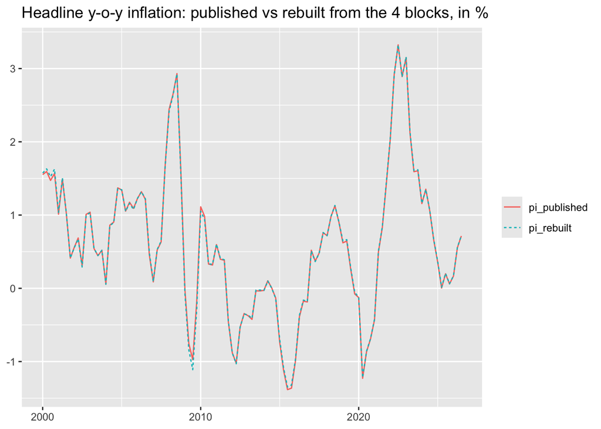

```r
reagg %>%
  pivot_longer(c(pi_published, pi_rebuilt), names_to = "series", values_to = "yoy") %>%
  ggplot(aes(date, yoy, colour = series, linetype = series)) +
  geom_line() +
  labs(title = "Headline y-o-y inflation: published vs rebuilt from the 4 blocks, in %",
       colour = NULL, linetype = NULL, x = NULL, y = NULL)
```

```r
write_csv(reagg, here("output", "reaggregation_check.csv"))
```

The four blocks rebuild headline inflation almost exactly: the average gap is 0.016 percentage points and the largest 0.14 pp (2009Q3). The small gap comes from linking at the Q4 average instead of December and from rounding in the published indices. Forecasting the four blocks and aggregating them with the CPI weights therefore gives a valid forecast of headline inflation.